# Take-Home Exercise 2: Geospatial Analytics for Social Good - Thailand Drug Abuse Case Study

Author

Han Ming Yan

Published

October 8, 2024

Modified

October 13, 2024

Abstract

In this exercise, we apply geospatial analysis techniques to study the distribution of drug use cases in Thailand at the provincial level from 2017 to 2022. By leveraging global and local spatial autocorrelation methods, we aim to uncover patterns, detect clusters and hotspots, and investigate how these trends evolve over time.

Keywords

Geospatial Analysis, Drug Abuse, Spatial Autocorrelation, Thailand, Clusters, Hotspots

## 0.1 Introduction

In this analysis, we explore the spatial distribution of drug use in Thailand from 2017 to 2022 using geospatial data and analysis methods. Drug abuse remains a significant social issue, particularly among youth, with the number of users continuing to rise. This exercise leverages geographic information system (GIS) tools to explore how drug use patterns are distributed across Thailand’s provinces and whether spatial dependencies exist in these patterns.

Thailand’s geopolitical position near the Golden Triangle, a major drug-producing region, further complicates its drug abuse situation. This study aims to identify spatial correlations, clusters, outliers, and hotspots in drug use cases over time.

# 1 **Overview**

This take-home exercise focuses on the application of geospatial analysis methods to explore and analyze the spatial distribution of drug abuse in Thailand at the provincial level from 2017 to 2022. We aim to detect spatial clusters, outliers, and hotspots, while also assessing how these trends evolve over time. By leveraging global and local spatial autocorrelation methods, we aim to uncover key patterns in the distribution of drug use cases in Thailand.

## 1.1 **Data used**

For this study, two main data sources were utilized: - **Thailand Drug Offenses (2017-2022)**, sourced from [Kaggle](https://www.kaggle.com/datasets) - **Thailand Subnational Administrative Boundaries**, sourced from [HDX](https://data.humdata.org/dataset)

These datasets provided the necessary drug abuse indicators at the provincial level and the geographical boundaries required for the spatial analysis.

Tools used: - **sf**: for managing and manipulating geospatial data. - **tidyverse**: for general data wrangling and visualization. - **sfdep**: for performing spatial autocorrelation analysis.

**The Task**

The tasks for this take-home exercise are as follows:

1. **Data Preparation**:
   - Using functions from **sf** and **tidyverse**, import the Thailand drug abuse data and administrative boundary data.
   - Create a spatial layer for Thailand provinces and a drug abuse indicators layer.
2. **Global Spatial Autocorrelation**:
   - Perform global spatial autocorrelation using Moran’s I to assess if drug abuse patterns are spatially random or dependent.
3. **Local Spatial Autocorrelation**:
   - Perform local spatial autocorrelation to detect spatial clusters, outliers, and hotspots using Local Moran’s I.
4. **Visualizing Spatial Patterns**:
   - Use appropriate **ggplot2** and **tmap** functions to visualize the spatial patterns of drug use cases over time.
5. **Describe Findings**:
   - Describe the spatial patterns revealed by the analysis and how these patterns evolved from 2017 to 2022.

**Grading Criteria**

1. **Geospatial Data Wrangling (20 marks)**:
   - You will be evaluated based on your ability to use R functions to import, clean, and prepare the geospatial data.
2. **Spatial Analysis (30 marks)**:
   - This includes performing the global and local spatial autocorrelation analyses and deriving insights from the patterns.
3. **Geovisualization (20 marks)**:
   - Your ability to effectively communicate the analysis results through visualizations will be assessed.
4. **Reproducibility (15 marks)**:
   - The exercise must be well-documented, and the code should be clear and easy to follow.
5. **Bonus (15 marks)**:
   - Demonstrate any advanced methods beyond what was covered in class.

## 1.2 **Installing and Loading the R Packages**

Before proceeding with the analysis, it is essential to install and load the required R packages:

- [`sf`](https://rdrr.io/github/r-spatial/sf/man/sf-package.html) : provides a standardised way to encode spatial vector data in R environment, facilitating spatial data operations and analysis.
- [`st`](https://rdrr.io/cran/sf/man/st.html) : creats simple features from numeric vectors, matrices, or lists, enabling the representation and manipulation of spatial structures in R.
- [`tidyverse`](https://www.tidyverse.org/) : a collection of R packages designed for data science. All packages share an underlying design philosophy, grammar, and data structure.
- [`sfdep`](https://cran.r-project.org/web/packages/spdep/) : for computing spatial weights, global and local spatial autocorrelation statistics
- [`tmap`](https://cran.r-project.org/web/packages/tmap/) : for creating static and interactive visualisations and maps.
- [`ggplot2`](https://cran.r-project.org/web/packages/ggplot2/) : for creating advanced visualisations, graphics and maps using the Grammar of Graphics.

```r
# Install and load necessary packages
pacman::p_load(sf, tidyverse, sfdep, tmap, readr, ggplot2, spdep)
```

## 1.3 **Importing and Transforming Geospatial Data**

In this section, `st_read()` of **sf** package will be used to import **`THALILAND_BORDERS_2022`** dataset into R environment.

```r
adm0 <- st_read("data/geospatial/tha_admbnda_adm0_rtsd_20220121.shp")
adm1 <- st_read("data/geospatial/tha_admbnda_adm1_rtsd_20220121.shp")
# Display the structure of the datasets
# glimpse(adm0)
# glimpse(adm1)
```

We will verify the coordinate reference systems of the tainan object to ensure the assignment of the correct CRS value. WGS 84 should be the correct reference.

```r
st_crs(adm1)
```

```
Coordinate Reference System:
  User input: WGS 84
  wkt:
GEOGCRS["WGS 84",
    DATUM["World Geodetic System 1984",
        ELLIPSOID["WGS 84",6378137,298.257223563,
            LENGTHUNIT["metre",1]]],
    PRIMEM["Greenwich",0,
        ANGLEUNIT["degree",0.0174532925199433]],
    CS[ellipsoidal,2],
        AXIS["latitude",north,
            ORDER[1],
            ANGLEUNIT["degree",0.0174532925199433]],
        AXIS["longitude",east,
            ORDER[2],
            ANGLEUNIT["degree",0.0174532925199433]],
    ID["EPSG",4326]]
```

Next, we will generate a plot of the adm1 object to visualise its structure.

```r
tmap_mode("plot")
```

```
tmap mode set to plotting
```

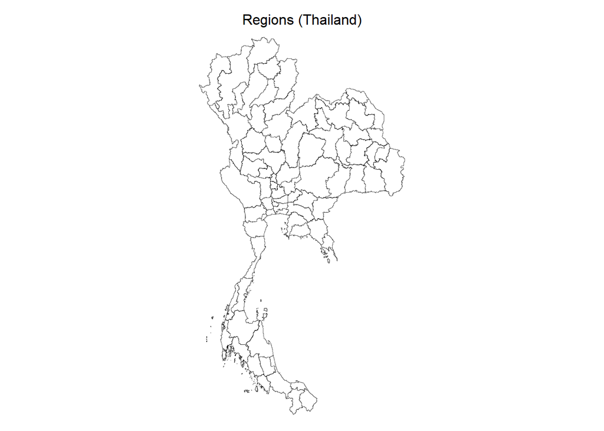

```r
tm_shape(adm1)+
  tm_fill(col="white")+
  tm_borders(col = "black", lwd=0.3, alpha=0.6)+
  tm_layout(
    main.title = "Regions (Thailand)",
    main.title.size = 1,
    main.title.position = "center",
    legend.show = FALSE,
     frame = FALSE)
```

## 1.4 **Importing Aspatial Data**

In this section, we use the `read_csv()` function from the **`readr`** package to import the aspatial dataset containing drug offenses in Thailand into the R environment. The output of this step is a data frame.

```r
drug_data <- read_csv("data/aspatial/thai_drug_offenses_2017_2022.csv")
# glimpse(drug_data)
```

## 1.5 **Spatial Data Wrangling**

After importing the drug abuse data, we need to merge it with the spatial dataset containing Thailand’s provincial boundaries. This step prepares the data for spatial analysis.

### 1.5.1 Inspect and Clean the Data

Before merging the datasets, it’s important to ensure consistency between the province names in both the spatial and aspatial datasets. If there are discrepancies in the naming conventions, we must clean and standardize the province names to avoid mismatches.

For instance, in the aspatial dataset, some province names differ from the names in the spatial dataset. For example:

- “Loburi” in `drug_data` should be standardized to “Lop Buri” in `adm1`.

Here’s how we clean the data by updating inconsistent province names:

```r
library(dplyr)

drug_data <- drug_data %>%
  mutate(
    province_en = recode(province_en,
                         "buogkan" = "Bueng Kan",
                         "Loburi" = "Lop Buri")
  )

head(drug_data)
```

```
# A tibble: 6 × 5
  fiscal_year types_of_drug_offenses no_cases province_th   province_en
        <dbl> <chr>                     <dbl> <chr>         <chr>
1        2017 drug_use_cases            11871 กรุงเทพมหานคร  Bangkok
2        2017 drug_use_cases              200 ชัยนาท         Chai Nat
3        2017 drug_use_cases              553 นนทบุรี         Nonthaburi
4        2017 drug_use_cases              450 ปทุมธานี        Pathum Thani
5        2017 drug_use_cases              378 พระนครศรีอยุธยา Phra Nakhon Si Ayut…
6        2017 drug_use_cases              727 ลพบุรี          Lop Buri
```

### 1.5.2 **Merging Data**

After cleaning the province names, we can merge the `drug_data` with the `adm1` shapefile. This step ensures that both the drug offense data and the provincial boundaries are linked together.

```r
# Inspect unique province names in both datasets
# unique(drug_data$province_en)
# unique(adm1$ADM1_EN)


# Perform the join on province_en and ADM1_EN
drug_data_sf <- adm1 %>%
  left_join(drug_data, by = c("ADM1_EN" = "province_en"))


# Check if the total number of provinces matches both datasets
unique(drug_data_sf$ADM1_EN)
```

```
 [1] "Bangkok"                  "Samut Prakan"
 [3] "Nonthaburi"               "Pathum Thani"
 [5] "Phra Nakhon Si Ayutthaya" "Ang Thong"
 [7] "Lop Buri"                 "Sing Buri"
 [9] "Chai Nat"                 "Saraburi"
[11] "Chon Buri"                "Rayong"
[13] "Chanthaburi"              "Trat"
[15] "Chachoengsao"             "Prachin Buri"
[17] "Nakhon Nayok"             "Sa Kaeo"
[19] "Nakhon Ratchasima"        "Buri Ram"
[21] "Surin"                    "Si Sa Ket"
[23] "Ubon Ratchathani"         "Yasothon"
[25] "Chaiyaphum"               "Amnat Charoen"
[27] "Bueng Kan"                "Nong Bua Lam Phu"
[29] "Khon Kaen"                "Udon Thani"
```

[output cut: 24 more lines]

```r
# drug_data_sf <- drug_data_sf %>%
#   filter(ADM1_EN != "Phetchabun")
```

### 1.5.3 **Handling Missing Data**

Sometimes, not all provinces may match perfectly during the join, leading to missing values. It’s important to check for any missing data and handle it appropriately.

```r
unique(drug_data_sf$types_of_drug_offenses)
```

```
 [1] "drug_use_cases"
 [2] "suspects_in_drug_use_cases"
 [3] "possession_cases"
 [4] "suspects_in_possession_cases"
 [5] "possession_with_intent_to_distribute_cases"
 [6] "suspects_in_possession_with_intent_to_distribute_cases"
 [7] "trafficking_cases"
 [8] "suspects_in_trafficking_cases"
 [9] "production_cases"
[10] "suspects_in_production_cases"
[11] "import_cases"
[12] "suspects_in_import_cases"
[13] "export_cases"
[14] "suspects_in_export_cases"
[15] "conspiracy_cases"
[16] "suspects_in_conspiracy_cases"
```

### 1.5.4 Handle Missing Data

Sometimes, the join might not find matches for all provinces. You should check for `NA` values and decide how to handle them (e.g., remove rows, fill missing values, etc.).

```r
# Check for missing values after the join
missing_provinces <- drug_data_sf %>% filter(is.na(fiscal_year))
print(missing_provinces)
```

```
Simple feature collection with 0 features and 20 fields
Bounding box:  xmin: NA ymin: NA xmax: NA ymax: NA
Geodetic CRS:  WGS 84
 [1] Shape_Leng             Shape_Area             ADM1_EN
 [4] ADM1_TH                ADM1_PCODE             ADM1_REF
 [7] ADM1ALT1EN             ADM1ALT2EN             ADM1ALT1TH
[10] ADM1ALT2TH             ADM0_EN                ADM0_TH
[13] ADM0_PCODE             date                   validOn
[16] validTo                fiscal_year            types_of_drug_offenses
[19] no_cases               province_th            geometry
<0 rows> (or 0-length row.names)
```

### 1.5.5 **Preparing Data for Spatial Analysis**

Now that the data is merged, it’s ready for further analysis, including global and local spatial autocorrelation, visualization, and clustering.

### 1.5.6 **Ensuring Data is in sf Format**

For visualization purposes, the data should be in `sf` format. We check and verify that the `drug_data_sf` object is in the correct format for further processing.

```r
class(drug_data_sf)
```

```
[1] "sf"         "data.frame"
```

## 1.6 **Analysis Workflow**

In this section, we will focus on visualizing and analyzing two key types of drug-related offenses: **trafficking cases** and **possession with intent to distribute cases**. Here’s why we chose these categories:

### 1.6.1 **Justification for Choosing These Categories:**

1. **Trafficking Cases:**
   - **Relevance**: Drug trafficking is often associated with organized crime and the movement of narcotics across regions. Given Thailand’s proximity to the Golden Triangle, a major drug-producing region, analyzing trafficking cases can help uncover transit routes and regions heavily involved in the drug trade.
   - **Insight**: This analysis can reveal provinces that play a major role in the drug trade, both within and outside Thailand.
2. **Possession with Intent to Distribute Cases:**
   - **Relevance**: This category focuses on individuals caught with drugs intended for sale, reflecting distribution networks. It helps identify not just end-users but those involved in drug distribution operations.
   - **Insight**: Combining this with trafficking data gives a comprehensive picture of both large-scale trafficking operations and smaller distribution networks.

### 1.6.2 Example Workflow:

1. **Data Exploration**: Explore the number of drug cases across provinces and over time.
2. **Data Aggregation**: You might want to aggregate the data by `fiscal_year` to calculate statistics such as total drug cases per province over the years.

### 1.6.3 **Aggregating Data by Year and Offense Type**

We can also break down the data by year and create visualizations for both **trafficking cases** and **possession with intent to distribute cases** across multiple years.

```r
# Function to split the data by offense type and year
split_data_by_year_type <- function(data, offense_type) {

  filtered_data <- data %>%
    filter(types_of_drug_offenses == offense_type) %>%
    select_if(~ any(!is.na(.)))  # Remove columns that are entirely NA

  years <- unique(filtered_data$fiscal_year)

  for (year in years) {
    # Filter data for each year
    year_data <- filtered_data %>%
      filter(fiscal_year == year)

    # Dynamically assign the data frame to a variable named by year
    assign(paste0(offense_type, "_data_", year), year_data, envir = .GlobalEnv)
  }
}

# for possession with intent to distribute cases
split_data_by_year_type(drug_data_sf, "possession_with_intent_to_distribute_cases")

# for trafficking cases
split_data_by_year_type(drug_data_sf, "trafficking_cases")
```

### 1.6.4 **Visualizing Drug Offense Data**

We will now create maps to visualize the spatial distribution of these two categories of drug offenses across Thailand for specific years. This helps identify high-risk areas for trafficking and drug distribution.

```
Legend labels were too wide. The labels have been resized to 0.72, 0.56, 0.56, 0.56, 0.48, 0.41. Increase legend.width (argument of tm_layout) to make the legend wider and therefore the labels larger.
```

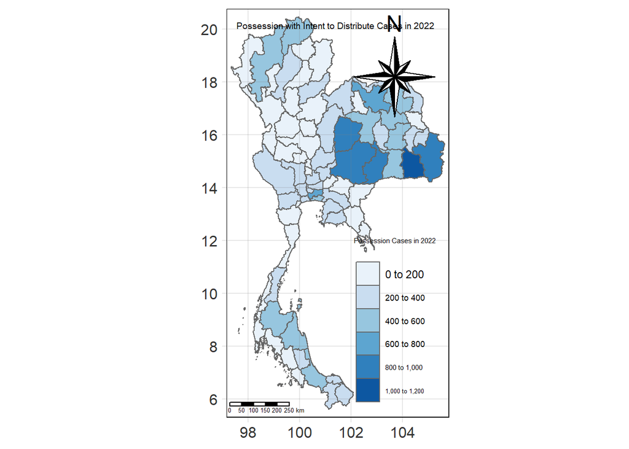

```r
# Create map for possession with intent to distribute cases in 2012
tm_shape(possession_with_intent_to_distribute_cases_data_2022) +
  tm_polygons("no_cases", title = "Possession Cases in 2022", palette = "Blues") +
  tm_layout(title = "Possession with Intent to Distribute Cases in 2022",
            main.title.position = "center",
            main.title.size = 2,
            main.title.fontface = "bold",
            legend.title.size = 1.8,
            legend.text.size = 1.3,
            frame = TRUE) +
  tm_borders(alpha = 0.5) +
  tm_compass(type="8star", text.size = 1.5, size = 3, position=c("RIGHT", "TOP")) +
  tm_scale_bar(position=c("LEFT", "BOTTOM"), text.size=1.2) +
  tm_grid(labels.size = 1,alpha =0.2)
```

```r
# Check the unique values in the fiscal_year column
unique(drug_data_sf$fiscal_year)
```

```
[1] 2017 2018 2019 2020 2021 2022
```

```r
# Set tmap mode to plot
tmap_mode("plot")
```

```
tmap mode set to plotting
```

```
Some legend labels were too wide. These labels have been resized to 0.62. Increase legend.width (argument of tm_layout) to make the legend wider and therefore the labels larger.
```

[output not shown]

[output not shown]

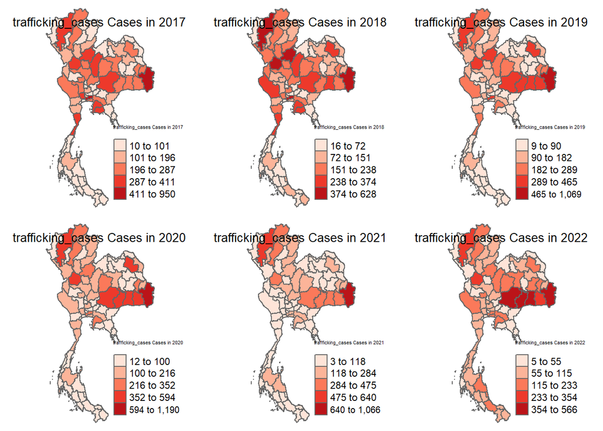

```r
# Function to create map by year and offense type
create_maps_by_year <- function(data, offense_type) {

  # Filter the data by offense type
  filtered_data <- data %>%
    filter(types_of_drug_offenses == offense_type) %>%
    select_if(~ any(!is.na(.)))  # Remove columns that are entirely NA

  # Get unique years
  years <- unique(filtered_data$fiscal_year)

  # List to store maps
  map_list <- list()

  # Loop over each year and create a map for that year
  for (year in years) {
    # Filter data by year
    year_data <- filtered_data %>%
      filter(fiscal_year == year)

    # Create the map for this year
    map <- tm_shape(year_data) +
      tm_polygons("no_cases",  # Assuming 'no_cases' holds the values
                  title = paste(offense_type, "Cases in", year),
                  palette = ifelse(offense_type == "trafficking_cases", "Reds", "Blues"),
                  style = "jenks") +
      tm_layout(title = paste(offense_type, "Cases in", year),
                frame = FALSE) +
      tm_borders()

    # Add the map to the list
    map_list[[as.character(year)]] <- map
  }

  return(map_list)
}

# Create maps for trafficking cases by year
trafficking_maps <- create_maps_by_year(drug_data_sf, "trafficking_cases")

# Create maps for possession with intent to distribute cases by year
possession_maps <- create_maps_by_year(drug_data_sf, "possession_with_intent_to_distribute_cases")

# Arrange trafficking maps side by side
tmap_arrange(trafficking_maps[[1]], trafficking_maps[[2]], trafficking_maps[[3]],
             trafficking_maps[[4]], trafficking_maps[[5]], trafficking_maps[[6]])
```

```
Some legend labels were too wide. These labels have been resized to 0.62, 0.55, 0.55. Increase legend.width (argument of tm_layout) to make the legend wider and therefore the labels larger.
```

[output not shown]

[output not shown]

[output not shown]

[output not shown]

```
Some legend labels were too wide. These labels have been resized to 0.62. Increase legend.width (argument of tm_layout) to make the legend wider and therefore the labels larger.
```

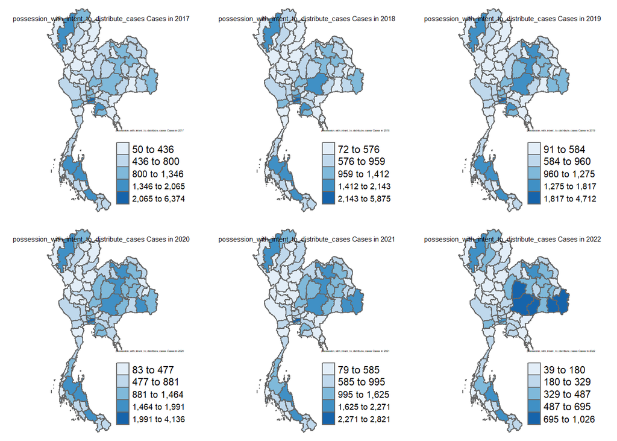

```r
# Arrange possession maps side by side
tmap_arrange(possession_maps[[1]], possession_maps[[2]], possession_maps[[3]],
             possession_maps[[4]], possession_maps[[5]], possession_maps[[6]])
```

### 1.6.5 **Handling Isolated Regions with Spatial Buffers**

In spatial analysis, some regions may not have immediate neighbors due to their geographic isolation, which can affect the spatial autocorrelation analysis. To address this, we apply a **100-meter buffer** to the dataset. This ensures that isolated regions are included in the contiguity analysis by artificially creating nearby neighbors through small adjustments in their spatial boundaries.

The buffered data is then used to compute **Queen contiguity neighbors**, which identify neighboring provinces that share borders, including those created by the buffer. This method helps ensure that no regions are left without neighbors, which is crucial for calculating spatial weights and conducting further spatial analysis.

```r
# Apply a small buffer to the dataset to create neighbors for isolated regions
buffered_data <- st_buffer(trafficking_cases_data_2022, dist = 100)  # 100 meters buffer, adjust as necessary

trafficking_cases_nb_q <- st_contiguity(buffered_data, queen=TRUE)

summary(trafficking_cases_nb_q)
```

```
Neighbour list object:
Number of regions: 77
Number of nonzero links: 324
Percentage nonzero weights: 5.464665
Average number of links: 4.207792
Link number distribution:

 1  2  3  4  5  6  7  8  9
 4  9 14 17 18  6  7  1  1
4 least connected regions:
12 14 23 67 with 1 link
1 most connected region:
29 with 9 links
```

Similarly, we apply the same process for **possession with intent to distribute cases**:

```r
 buffered_data <- st_buffer(possession_with_intent_to_distribute_cases_data_2022, dist = 100)
possession_cases_nb_q <- st_contiguity(buffered_data, queen=TRUE)

summary(possession_cases_nb_q)
```

```
Neighbour list object:
Number of regions: 77
Number of nonzero links: 324
Percentage nonzero weights: 5.464665
Average number of links: 4.207792
Link number distribution:

 1  2  3  4  5  6  7  8  9
 4  9 14 17 18  6  7  1  1
4 least connected regions:
12 14 23 67 with 1 link
1 most connected region:
29 with 9 links
```

By using buffered data and Queen contiguity, we ensure that all regions, including those that may have been isolated, are part of the spatial neighbor analysis. This enhances the robustness of our spatial autocorrelation and clustering results.

## 1.7 **Computing Row-Standardised Weight Matrix**

In spatial autocorrelation analysis, spatial weights are assigned to neighboring polygons to represent the relationships between them. In this study, we use a row-standardized weight matrix. Row standardization ensures that the sum of the weights for each polygon equals 1, making it easier to interpret spatial relationships as an average of neighboring values.

We begin by checking for any provinces that might not have neighbors (isolated provinces), and then assign spatial weights using the **Queen contiguity method**.

[`st_weights()`](https://rdrr.io/cran/sfdep/man/st_weights.html) function from `sfdep` pacakge can be used to supplement a neighbour list with spatial weights based on the chosen coding scheme. There are as least 5 different coding scheme styles supported by this function:

- `B` is the basic binary coding
- `W` is row standardised (sums over all links to n)
- `C` is globally standardised (sums over all links to n)
- `U` is equal to C divided by the number of neighbours (sums over all links to unity)
- `S` is the variance-stabilizing coding scheme proposed by Tiefelsdorf et al. (1999) (sums over all links to n).

In this study, we will use row-standardised weight matrix (style=`"W"`). Row standardisation of a matrix ensure that the sum of the values across each row add up to 1. This is accomplished by assigning the fraction 1/(# of neighbors) to each neighboring county then summing the weighted income values. Row standardisation ensures that all weights are between 0 and 1. This facilities the interpretation of operation with the weights matrix as an averaging of neighboring values, and allows for the spatial parameter used in our analyses to be comparable between models.

```r
# Check for isolated provinces
isolated_provinces <- which(card(trafficking_cases_nb_q) == 0)

if(length(isolated_provinces) > 0) {
  print("The following provinces have no neighbors:")
  print(isolated_provinces)
} else {
  print("No isolated provinces found.")
}
```

```
[1] "No isolated provinces found."
```

```r
# Create a neighbors list based on shared borders with zero.policy set to TRUE
trafficking_cases_wm_rs <- st_weights(trafficking_cases_nb_q, style = "W")


# Create a neighbors list based on shared borders
# trafficking_cases_wm_rs <- st_weights(trafficking_cases_nb_q, style="W")
```

```r
# Check for isolated provinces
isolated_provinces <- which(card(possession_cases_nb_q) == 0)

if(length(isolated_provinces) > 0) {
  print("The following provinces have no neighbors:")
  print(isolated_provinces)
} else {
  print("No isolated provinces found.")
}
```

```
[1] "No isolated provinces found."
```

```r
# Create a neighbors list based on shared borders with zero.policy set to TRUE
possession_cases_wm_rs <- st_weights(possession_cases_nb_q, style = "W")
```

## 1.8 **Global Spatial Autocorrelation (Moran’s I)**

## 1.9 **Global Moran’s** I

### 1.9.1 **Computing Global Moran’s** I

Moran’s I is the correlation coefficient for the relationship between a variable and its neighbouring values. Moran’s I describes how features differ from the values in the study area as a whole and quantifies how similar each region is with its neighbors and averages all these assessments. Moran’s I values usually range from –1 to 1. We can test spatial autocorrelation by following these hypotheses:

- **Null Hypothesis** H0:I=E[I]. This suggests there is no spatial autocorrelation.
- **Alternative Hypothesis** H1:I≠E[I]. This indicates the presence of spatial autocorrelation.

```r
# Perform global Moran's I test for trafficking cases
global_moran_test_trafficking <- global_moran_test(trafficking_cases_data_2022$no_cases,
                                                   trafficking_cases_nb_q,
                                                   trafficking_cases_wm_rs,
                                                   alternative = "greater")

# Output the results
print(global_moran_test_trafficking)
```

```
    Moran I test under randomisation

data:  x
weights: listw

Moran I statistic standard deviate = 2.3047, p-value = 0.01059
alternative hypothesis: greater
sample estimates:
Moran I statistic       Expectation          Variance
      0.170282435      -0.013157895       0.006334972
```

```r
# Perform global Moran's I test for possession cases
global_moran_test_possession <- global_moran_test(possession_with_intent_to_distribute_cases_data_2022$no_cases,
                                                  possession_cases_nb_q,
                                                  possession_cases_wm_rs,
                                                  alternative = "greater")

# Output the results
print(global_moran_test_possession)
```

```
    Moran I test under randomisation

data:  x
weights: listw

Moran I statistic standard deviate = 2.9812, p-value = 0.001436
alternative hypothesis: greater
sample estimates:
Moran I statistic       Expectation          Variance
      0.227615709      -0.013157895       0.006522818
```

### 1.9.2 **Global Moran’s I Test**

The Global Moran’s I test allows us to assess the strength and significance of spatial autocorrelation. We’ll use the `global_moran_test()` function to formally test if the observed spatial autocorrelation is statistically significant.

#### Hypotheses for Global Moran’s I Test:

- **Null Hypothesis (H₀)**: There is no spatial autocorrelation (Moran’s I = 0).
- **Alternative Hypothesis (H₁)**: There is positive spatial autocorrelation (Moran’s I > 0).

In this analysis, we are primarily interested in testing for positive spatial autocorrelation, where provinces with similar numbers of drug-related offenses are spatially clustered. We set `alternative = "greater"` to reflect this.

```r
# Global Moran's I Test for trafficking cases
moranI_trafficking <- global_moran_test(
  trafficking_cases_data_2022$no_cases,  # Numeric variable (drug-related offenses)
  trafficking_cases_nb_q,  # Neighbors list object
  trafficking_cases_wm_rs,  # Weights list
  alternative = "greater"
)

# Global Moran's I Test for possession with intent to distribute cases
moranI_possession <- global_moran_test(
  possession_with_intent_to_distribute_cases_data_2022$no_cases,  # Numeric variable (drug-related offenses)
  possession_cases_nb_q,  # Neighbors list object
  possession_cases_wm_rs,  # Weights list
  alternative = "greater"
)

# Output the test results
print(moranI_trafficking)
```

```
    Moran I test under randomisation

data:  x
weights: listw

Moran I statistic standard deviate = 2.3047, p-value = 0.01059
alternative hypothesis: greater
sample estimates:
Moran I statistic       Expectation          Variance
      0.170282435      -0.013157895       0.006334972
```

```r
print(moranI_possession)
```

```
    Moran I test under randomisation

data:  x
weights: listw

Moran I statistic standard deviate = 2.9812, p-value = 0.001436
alternative hypothesis: greater
sample estimates:
Moran I statistic       Expectation          Variance
      0.227615709      -0.013157895       0.006522818
```

### 1.9.3 **Analysis & Discussion**:

#### Trafficking Cases:

1. The Moran’s I statistic for **trafficking cases** is **0.1703**, which is positive and significantly different from the expected value of **-0.0132** under the null hypothesis of no spatial autocorrelation. This indicates a moderate positive spatial autocorrelation, meaning that provinces with similar numbers of trafficking-related offenses tend to be geographically clustered.
   - **Moran’s I Statistic**: 0.1703
   - **Expected Value**: -0.0132
   - **Variance**: 0.0063
   - **p-value**: 0.0106

   The p-value of **0.0106** is less than the significance threshold of 0.05, indicating that the observed clustering is statistically significant and unlikely to occur by chance. Therefore, we reject the null hypothesis and conclude that provinces with similar levels of trafficking offenses are spatially clustered.

   This suggests that trafficking operations are not randomly dispersed but concentrated in certain regions, likely influenced by geographic factors such as proximity to borders, trafficking routes, or urban centers.

#### **Possession with Intent to Distribute Cases**:

   The Moran’s I statistic for **possession with intent to distribute cases** is **0.2276**, which is also positive and significantly different from the expected value of **-0.0132**. This suggests a stronger positive spatial autocorrelation compared to the trafficking cases, meaning that provinces with similar numbers of possession cases are even more likely to be geographically clustered.
   - **Moran’s I Statistic**: 0.2276
   - **Expected Value**: -0.0132
   - **Variance**: 0.0065
   - **p-value**: 0.0014

   The p-value of **0.0014** is well below the 0.05 significance level, confirming that the spatial clustering of possession cases is highly significant. We reject the null hypothesis and conclude that the observed spatial pattern is not random.

   This result implies that drug distribution networks, as indicated by possession with intent to distribute cases, are heavily concentrated in specific regions, possibly influenced by local demand, supply chains, or enforcement activities.

   Both **trafficking cases** and **possession with intent to distribute cases** show significant positive spatial autocorrelation. This means that provinces with similar numbers of drug-related offenses tend to be geographically close to one another rather than randomly distributed across Thailand.
   - **Trafficking cases** exhibit moderate clustering, suggesting the presence of concentrated trafficking routes.
   - **Possession cases** show stronger clustering, indicating specific regions where drug distribution networks are more active.

   These findings provide valuable insights for law enforcement and policy-makers in identifying high-risk areas and focusing resources on regions where drug-related activities are concentrated.

## 1.10 **Local Spatial Autocorrelation (Local Moran’s I)**

Local Indicators of Spatial Association (LISA), such as Local Moran’s I, are used to identify spatial clusters and outliers by examining the relationship between a location and its neighbors. While global Moran’s I gives us an overall sense of spatial autocorrelation, local Moran’s I allows us to detect spatial patterns at a more granular level.

In this context, we will examine whether provinces in Thailand exhibit spatial clustering for two types of drug-related offenses: **trafficking cases** and **possession with intent to distribute cases**. This can help identify regions with significant concentrations of offenses and detect spatial outliers where a province’s offense levels deviate from its neighbors.

```r
# Create the contiguity-based neighbor list for trafficking and possession cases
# trafficking_cases_nb_q <- st_contiguity(trafficking_cases_data_2022, queen=TRUE)
# possession_cases_nb_q <- st_contiguity(possession_with_intent_to_distribute_cases_data_2022, queen=TRUE)
#
# # Convert the neighbor lists into row-standardized spatial weights
# trafficking_cases_wm_rs <- st_weights(trafficking_cases_nb_q, style = "W")
# possession_cases_wm_rs <- st_weights(possession_cases_nb_q, style = "W")
```

### 1.10.1 **Computing Local Moran’s I**

We use the `local_moran()` function from the `sfdep` package to compute the Local Moran’s I statistic for each province based on the number of drug-related cases.

```r
# Local Moran's I for trafficking cases
local_moran_trafficking <- local_moran(trafficking_cases_data_2022$no_cases, trafficking_cases_nb_q, trafficking_cases_wm_rs)

# Local Moran's I for possession with intent to distribute cases
local_moran_possession <- local_moran(possession_with_intent_to_distribute_cases_data_2022$no_cases, possession_cases_nb_q, possession_cases_wm_rs)

# View the results (Ii: Local Moran's I, E.Ii: expected value, Var.Ii: variance, Z.Ii: standard deviate, Pr(z): p-value)
head(local_moran_trafficking)
```

```
            ii          eii     var_ii       z_ii      p_ii p_ii_sim
1 -0.216764189  0.008496544 0.19016436 -0.5165602 0.6054632    0.712
2  0.505498752 -0.006633475 0.28444498  0.9602470 0.3369309    0.356
3 -0.005170613 -0.010124057 0.13858182  0.0133062 0.9893835    0.816
4  0.102651999 -0.007622748 0.01899992  0.8000187 0.4236999    0.460
5  0.158486860 -0.008223750 0.02134358  1.1411156 0.2538218    0.208
6  0.144545046 -0.002272326 0.03205338  0.8200504 0.4121874    0.428
  p_folded_sim   skewness  kurtosis      mean    median     pysal
1        0.356  0.7965386 0.3974793  High-Low  High-Low  High-Low
2        0.178  1.2679570 1.0372514 High-High High-High High-High
3        0.408 -1.0089413 0.7074568   Low-Low  Low-High  Low-High
4        0.230 -0.8598083 0.5468490   Low-Low  High-Low   Low-Low
5        0.104 -1.0060551 2.1750579   Low-Low   Low-Low   Low-Low
6        0.216 -1.0685882 1.0124239   Low-Low   Low-Low   Low-Low
```

```r
head(local_moran_possession)
```

```
            ii           eii      var_ii        z_ii      p_ii p_ii_sim
1 -0.087178425 -0.1007039021 0.515154162  0.01884447 0.9849652    0.928
2  0.683113040 -0.0232390288 0.346866078  1.19933444 0.2303979    0.252
3 -0.082448066  0.0048038893 0.012285441 -0.78719040 0.4311704    0.392
4 -0.004673618  0.0038570914 0.003726239 -0.13974935 0.8888580    0.812
5  0.015199088  0.0009792999 0.000446880  0.67266316 0.5011616    0.512
6  0.236323825 -0.0242952474 0.116411046  0.76385179 0.4449556    0.468
  p_folded_sim   skewness   kurtosis      mean    median     pysal
1        0.464  0.5561153 0.04341705  High-Low  High-Low  High-Low
2        0.126  1.3874509 2.32826986 High-High High-High High-High
3        0.196 -1.0556402 1.70898493  Low-High High-High  Low-High
4        0.406 -0.7073410 0.26929444   Low-Low  High-Low  Low-High
5        0.256 -0.6863978 1.32444037   Low-Low  High-Low   Low-Low
6        0.234 -0.9276461 1.09450761   Low-Low   Low-Low   Low-Low
```

The output provides:

- **Ii**: The Local Moran’s I statistic for each province.
- **E.Ii**: The expected value under the null hypothesis of no spatial autocorrelation.
- **Var.Ii**: The variance under the null hypothesis.
- **Z.Ii**: The Z-score for testing significance.
- **Pr(z)**: The p-value for testing whether the observed spatial pattern is significantly different from random.

### 1.10.2 **Identifying Clusters and Outliers**

We categorize the provinces into different types of spatial clusters based on the sign and significance of Local Moran’s I. Provinces can be classified as:

- **High-High**: High offense rates surrounded by other high-rate areas.
- **Low-Low**: Low offense rates surrounded by other low-rate areas.
- **High-Low**: High offense rates surrounded by low-rate areas (spatial outliers).
- **Low-High**: Low offense rates surrounded by high-rate areas (spatial outliers).

```r
# Append local Moran's I results to the trafficking data
trafficking_cases_data_2022 <- cbind(trafficking_cases_data_2022, local_moran_trafficking)

# Append local Moran's I results to the possession data
possession_with_intent_to_distribute_cases_data_2022 <- cbind(possession_with_intent_to_distribute_cases_data_2022, local_moran_possession)

# Rename the columns for better readability
colnames(trafficking_cases_data_2022)[ncol(trafficking_cases_data_2022) - 4:ncol(trafficking_cases_data_2022)] <- c("Ii", "E.Ii", "Var.Ii", "Z.Ii", "Pr.z")
colnames(possession_with_intent_to_distribute_cases_data_2022)[ncol(possession_with_intent_to_distribute_cases_data_2022) - 4:ncol(possession_with_intent_to_distribute_cases_data_2022)] <- c("Ii", "E.Ii", "Var.Ii", "Z.Ii", "Pr.z")
```

### 1.10.3 **Mapping Local Moran’s I and p-values**

We visualize the spatial patterns by creating choropleth maps of the Local Moran’s I statistics and the corresponding p-values.

Trafficking Cases:

```
Some legend labels were too wide. These labels have been resized to 0.59, 0.56, 0.56. Increase legend.width (argument of tm_layout) to make the legend wider and therefore the labels larger.
```

[figure not shown]

```r
# Mapping Local Moran's I for trafficking cases
tm_shape(trafficking_cases_data_2022) +
  tm_fill(col = "Ii", style = "pretty", palette = "RdBu", title = "Local Moran's I") +
  tm_borders(alpha = 0.5)
```

[figure not shown]

```r
# Mapping p-values for trafficking cases
tm_shape(trafficking_cases_data_2022) +
  tm_fill(col = "Pr.z", style = "pretty", palette = "-Blues", title = "p-values") +
  tm_borders(alpha = 0.5)
```

Possession:

```
Some legend labels were too wide. These labels have been resized to 0.59, 0.56, 0.56. Increase legend.width (argument of tm_layout) to make the legend wider and therefore the labels larger.
```

[figure not shown]

```r
# Similarly for possession cases
tm_shape(possession_with_intent_to_distribute_cases_data_2022) +
  tm_fill(col = "Ii", style = "pretty", palette = "RdBu", title = "Local Moran's I") +
  tm_borders(alpha = 0.5)
```

[figure not shown]

```r
tm_shape(possession_with_intent_to_distribute_cases_data_2022) +
  tm_fill(col = "Pr.z", style = "pretty", palette = "-Blues", title = "p-values") +
  tm_borders(alpha = 0.5)
```

#### **Analysis & Discussion**

From the Local Moran’s I analysis:

## 1.12 **References**

1. **Thailand Drug Offenses (2017-2022)**: Kaggle Dataset
2. **Thailand Subnational Administrative Boundaries**: HDX Dataset
3. **World Drug Report 2023**: UNODC Report
4. Khan, D. et al. (2017). *Hot spots, cluster detection and spatial outlier analysis of teen birth rates in the U.S., 2003–2012*. *Spatial and Spatio-temporal Epidemiology*.
5. **R Packages**:
   - **sf**, **tidyverse**, **sfdep**: Spatial data handling and geospatial analysis.
   - **ggplot2**, **tmap**: Data visualization.